# Check the Potr genomes mapped gene without annotation overlap

Nicolas Delhomme

2015-06-17

# 1 Setup

Set the working dir

```r
setwd("/mnt/picea/projects/aspseq/asp201/rna/BEDTools/")
```

Load libraries

```r
suppressPackageStartupMessages(library(Biostrings))
suppressPackageStartupMessages(library(genomeIntervals))
suppressPackageStartupMessages(library(pander))
suppressPackageStartupMessages(library(parallel))
suppressPackageStartupMessages(library(RColorBrewer))
suppressPackageStartupMessages(library(S4Vectors))
suppressPackageStartupMessages(library(VennDiagram))
```

Source helpers

```r
source("~/Git/UPSCb/src/R/gff3Utilities.R")
source("~/Git/UPSCb/src/R/sequenceUtilities.R")
source("~/Git/UPSCb/src/R/plot.multidensity.R")
```

Graphic params

```r
pal <- brewer.pal(8,"Dark2")
mar <- par("mar")
```

# 2 Analysis

## 2.1 IDs

Reading in all the pairwise subtract data

```r
res <- mclapply(dir(".",pattern=".*-no-ovl\\.gff3"),readGff3,mc.cores=6L)
names(res) <- sub("-synth.*-no-ovl\\.gff3","",dir(".",pattern=".*-no-ovl\\.gff3"))
```

Reading in all the complete gmap gff3 files

```r
gff3s <- mclapply(dir("../gmap/Potr",pattern=".*\\.gff3",full.names = TRUE),readGff3,mc.cores=6L)
names(gff3s) <- sub("\\.gff3","",dir("../gmap/Potr",pattern=".*\\.gff3"))
```

Create a list of IDs

```r
ID.list <- lapply(lapply(res,getGffAttribute,"ID"),as.vector)
```

Barplot them

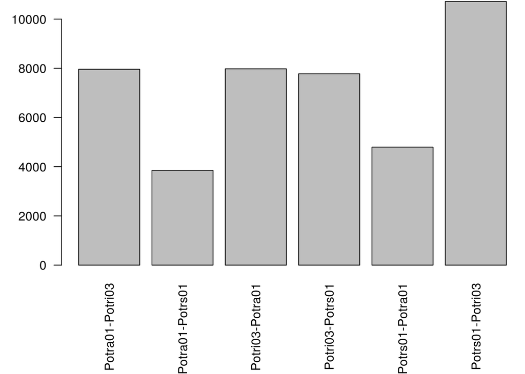

```r
par(mar=c(7.1,4.1,0.1,0.1))
barplot(elementLengths(ID.list),las=2)
```

```r
par(mar=mar)
```

Check the genes

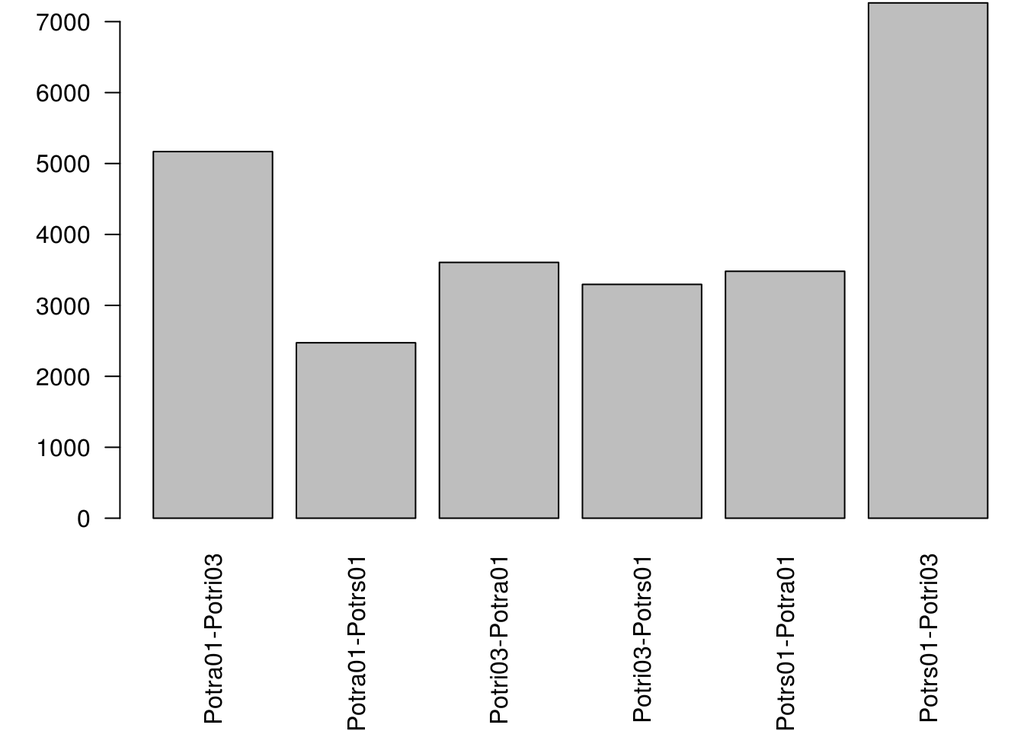

```r
par(mar=c(7.1,4.1,0.1,0.1))
barplot(elementLengths(sapply(lapply(ID.list,function(IDl){sub("\\.0\\.path.*","",IDl)}),unique)),las=2)
```

```r
par(mar=mar)
```

Write the ID lists

```r
dev.null <- mclapply(1:length(ID.list),function(i,IDl){
  write(IDl[[i]],file=paste(names(IDl)[i],"-no-ovl-IDs.txt",sep=""))
},ID.list)
```

How do they overlap within one species

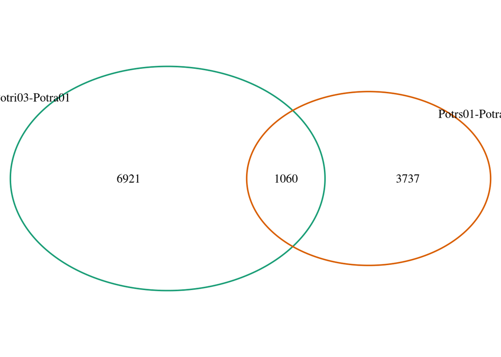

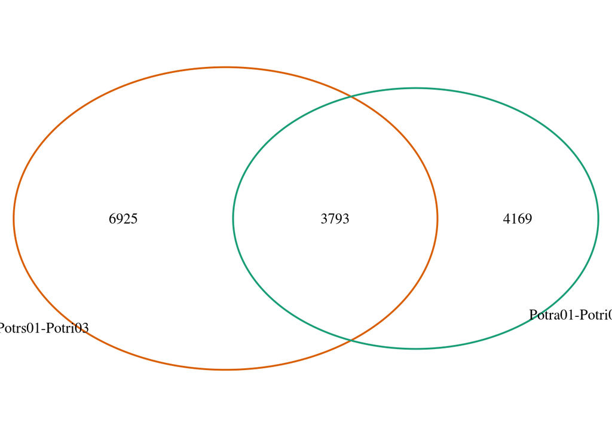

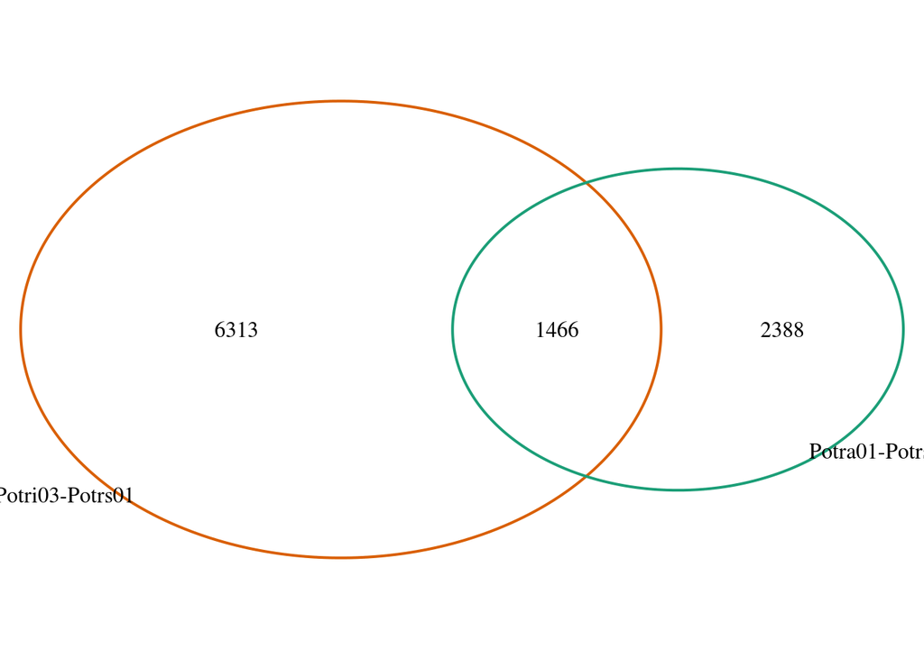

```r
dev.null <- lapply(split(ID.list,sub(".*-","",names(ID.list))),function(ls){
  plot.new()
  grid.draw(venn.diagram(ls,
                         filename=NULL,
                         col=pal[1:2],
                         category.names=names(ls)))
})
```

How many paths, i.e. how many truly uniquely mapping and non-overlapping.

```r
ID.list.orig <- ID.list
load("potrOvl30pGmapIDList.rda")
ID.list30 <- ID.list
ID.list <- ID.list.orig

ID.ovl <- mcmapply("%in%",
  mclapply(ID.list,function(ls){sub("\\.path.*","",ls)},mc.cores=6L),
  mclapply(ID.list30,function(ls){sub("\\.path.*","",ls)},mc.cores=6L),
  mc.cores=6L
)
```

On average half the mapped genes had been found in the other (the 30p) overlap

```r
pander(sapply(ID.ovl,table))
```

Table continues below

|  | Potra01-Potri03 | Potra01-Potrs01 | Potri03-Potra01 |
| --- | --- | --- | --- |
| **FALSE** | 4347 | 1655 | 4804 |
| **TRUE** | 3615 | 2199 | 3177 |

|  | Potri03-Potrs01 | Potrs01-Potra01 | Potrs01-Potri03 |
| --- | --- | --- | --- |
| **FALSE** | 6401 | 1190 | 5868 |
| **TRUE** | 1378 | 3607 | 4850 |

So let’s filter these away

```r
ID.list <- mcmapply("[",ID.list,ID.ovl,mc.cores=6L)
```

And plot the overlap again The overlap has strongly decreased

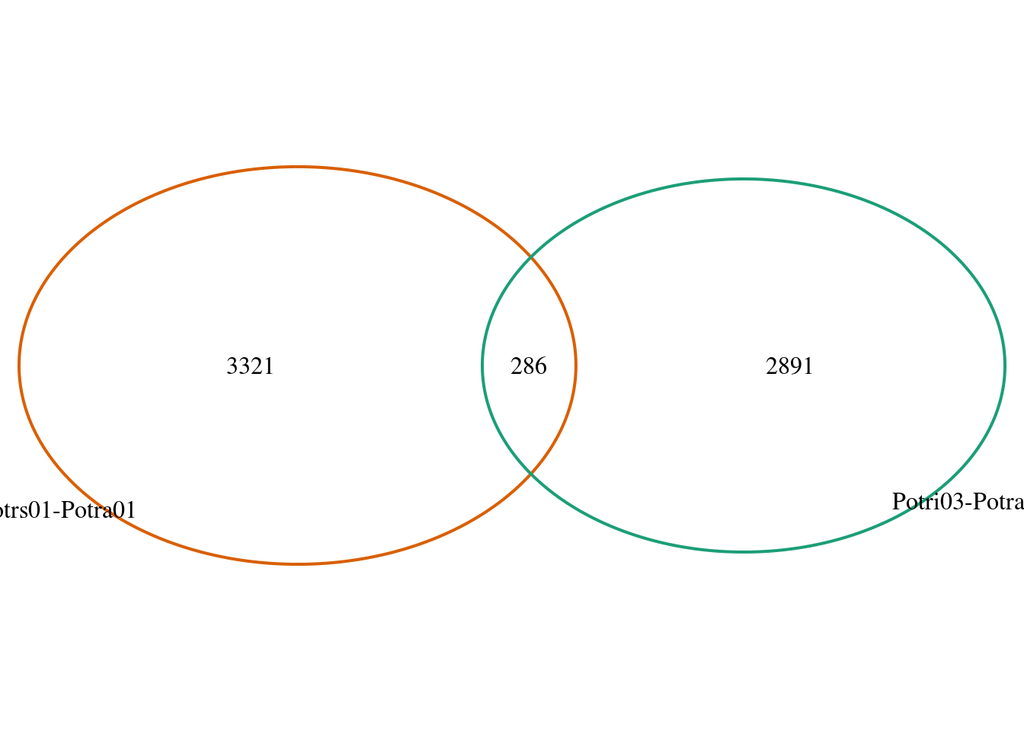

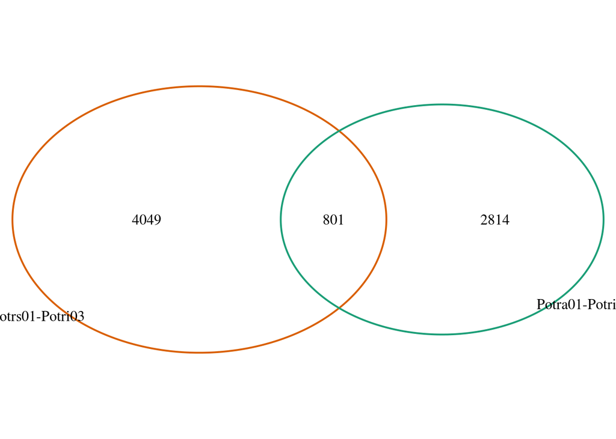

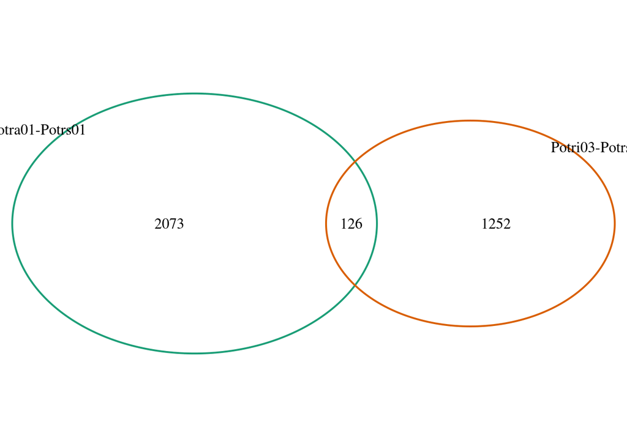

```r
dev.null <- lapply(split(ID.list,sub(".*-","",names(ID.list))),function(ls){
  plot.new()
  grid.draw(venn.diagram(ls,
                         filename=NULL,
                         col=pal[1:2],
                         category.names=names(ls)))
})
```

## 2.2 GFF3

Subtract the complete GFF3

```r
stopifnot(names(gff3s) == names(ID.list))
sgff3 <- mcmapply(extractFromGff3UsingGeneIDs,gff3s,ID.list,mc.cores=6L)

cov.idt <- mclapply(sgff3,function(gff){
  t(apply(getGffAttribute(gff[gff$type=="mRNA",],c("coverage","identity")),1,as.numeric))
},mc.cores=6L)
```

Here again it makes sense - as for the 70p and 30p overlap

1. Potra compared to Potrs seem to be a genome of higher heterozigosity (or worse assembly).
2. The shoulders of Potra and Potrs at 100 identity when aligned to Potri are hard to explain though. These might be very conserved genes, but why are they less frequent in Potrs? Because Potra is more collapsed?

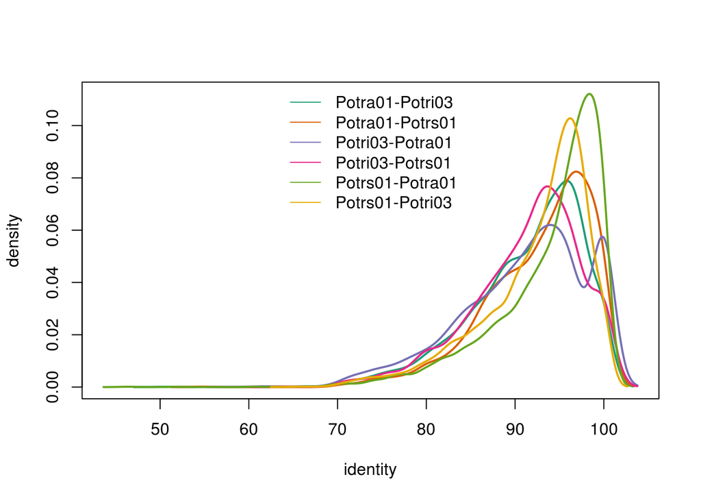

```r
plot.multidensity(lapply(cov.idt,function(m){m[,2]}),xlab="identity",lwd=2)
```

Most of the paths are fragmented.

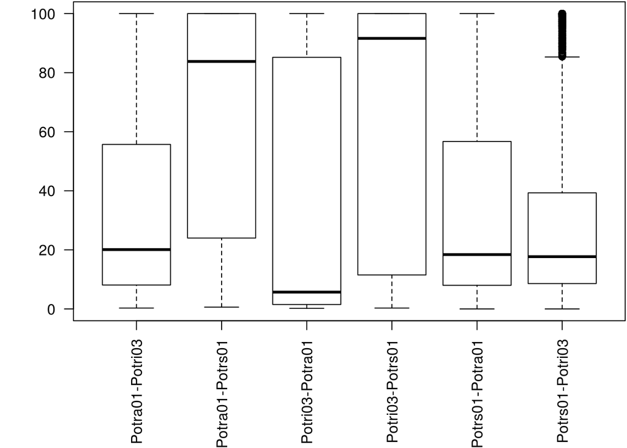

```r
par(mar=c(7.1,4.1,0.1,0.1))
boxplot(lapply(cov.idt,function(m){m[,1]}),las=2)
```

```r
par(mar=mar)
```

More clearly here, aligning to Potrs genes into Potra or Potri shows the least fragmentation. This is likely an artefact of the annotation (Maker and the Potrs lift-over will not have found/or lifted-over these).

Nevertheless, it shows that relatively few full length genes have been missed when aligning Potra.

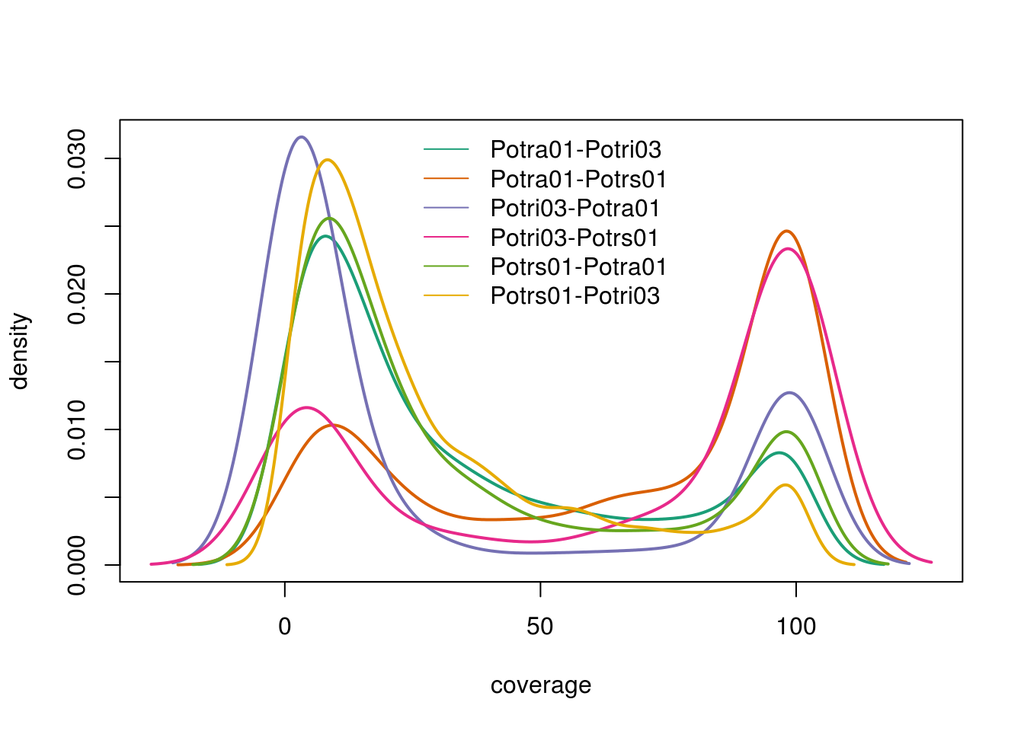

```r
plot.multidensity(lapply(cov.idt,function(m){m[,1]}),xlab="coverage",lwd=2,col=pal[1:6])
```

## 2.3 Sequences

Load the genomes

```r
Potra01 <- readDNAStringSet("/mnt/picea/storage/reference/Populus-tremula/v1.0/fasta/Potra01-genome.fa.gz")
Potri03 <- readDNAStringSet("/mnt/picea/storage/reference/Populus-trichocarpa/v3.0/fasta/Ptrichocarpa_v3.0_210.fa.gz")
Potrs01 <- readDNAStringSet("/mnt/picea/storage/reference/Populus-tremuloides/v1.0/fasta/Potrs01-genome.fa.gz")
```

Get the sequences (CDS and prot)

```r
splt <- split(sgff3,sub("-.*","",names(sgff3)))

## The extract function are already multithread, so no need to push more ;-)
CDSs <- unlist(lapply(1:length(splt),function(j,splt){
  lapply(1:length(splt[[j]]),function(i,spl,genome){
    eval(parse(text=paste("extractCdsFromGenome(spl[[i]],",genome,")")))
  },splt[[j]],names(splt)[j])
},splt))

Prots <- unlist(lapply(1:length(splt),function(j,splt){
  lapply(1:length(splt[[j]]),function(i,spl,genome){
    eval(parse(text=paste("extractProteinFromGenome(spl[[i]],",genome,")")))
  },splt[[j]],names(splt)[j])
},splt))

names(CDSs) <- names(Prots) <- names(res)
```

Check the Prot overlap

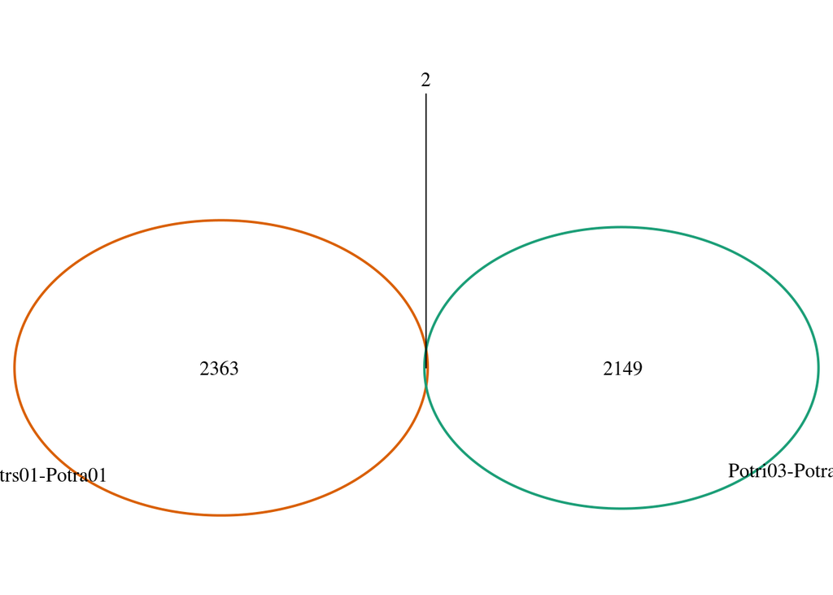

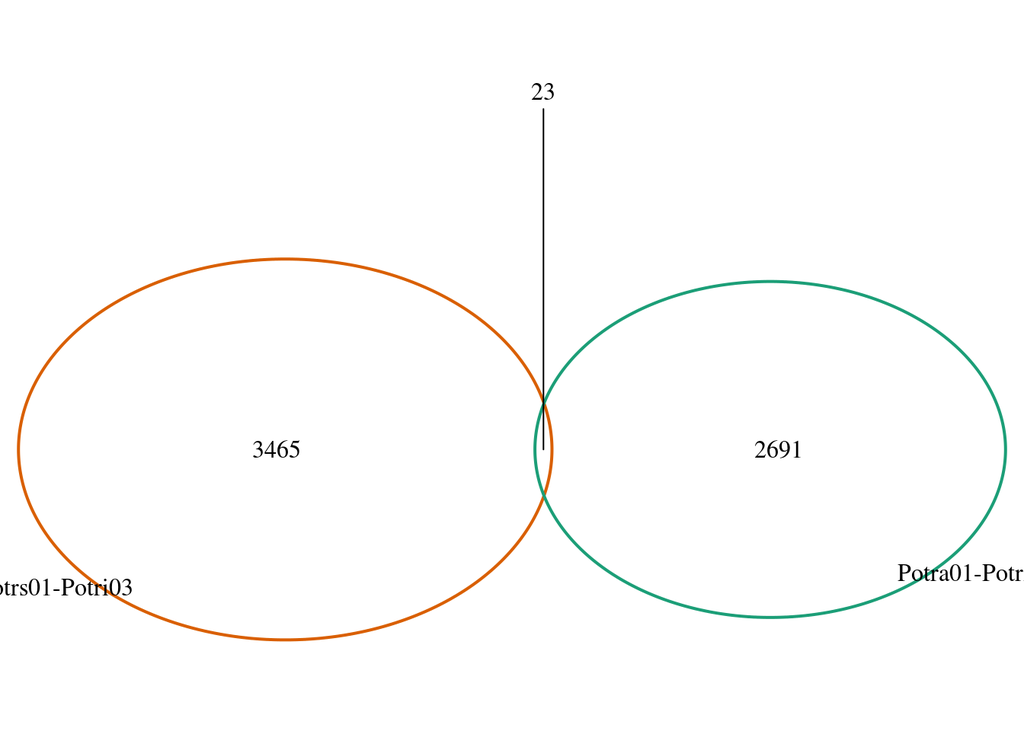

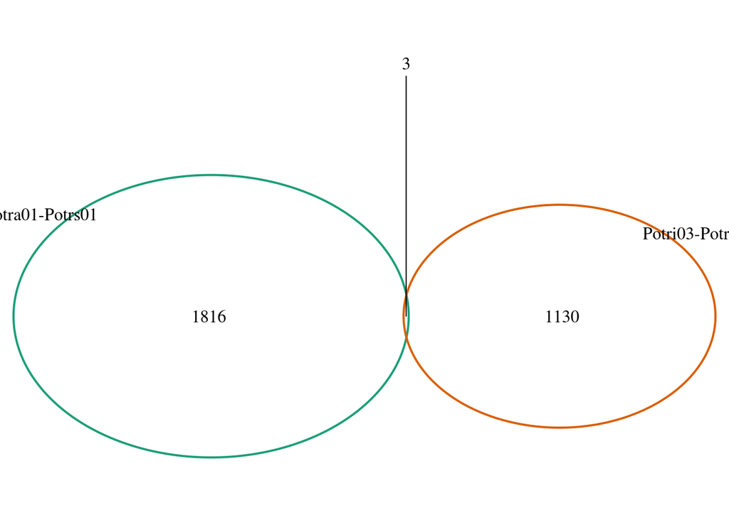

```r
dev.null <- lapply(split(Prots,sub(".*-","",names(Prots))),function(ls){
  plot.new()
  chars <- lapply(ls,as.character)
  grid.draw(venn.diagram(chars,
                         filename=NULL,
                         col=pal[1:2],
                         category.names=names(ls)))
})
```

Clean the proteins; use a min length of 30 AA

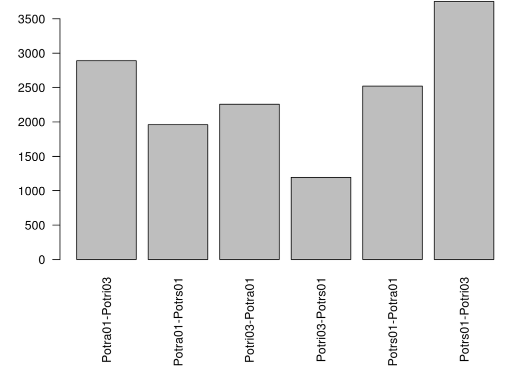

```r
cProts <- mcmapply("[",Prots,sapply(lapply(Prots,width),">=",30))
par(mar=c(7.1,4.1,0.1,0.1))
barplot(elementLengths(Prots),las=2)
```

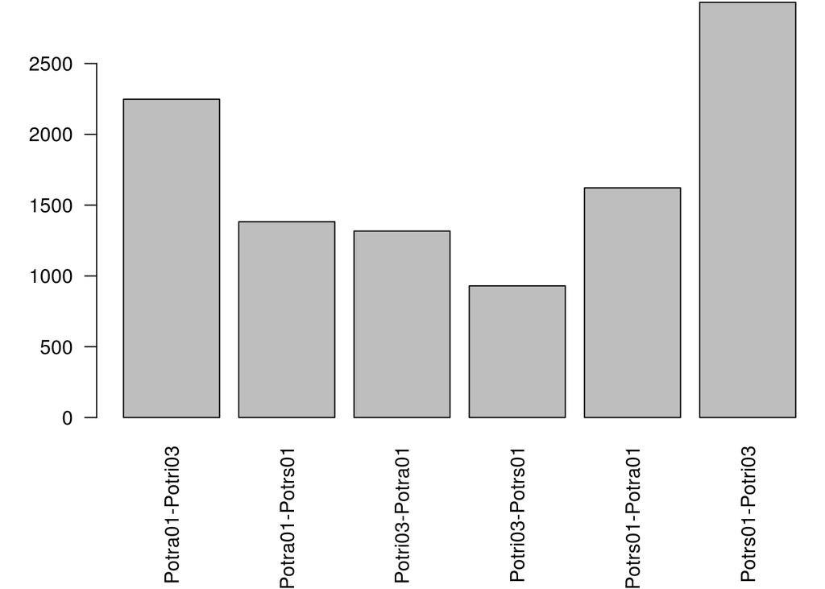

```r
barplot(elementLengths(cProts),las=2)
```

```r
par(mar=mar)
```

How many are coding

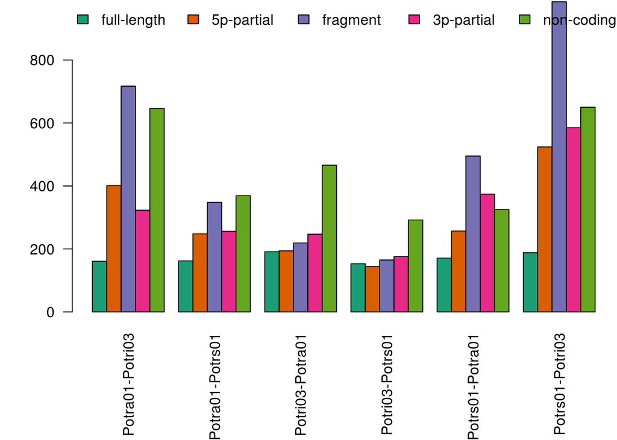

```r
prot.states <- mclapply(cProts,getProteinState,mc.cores=6L)
tabs <- sapply(prot.states,table)
par(mar=c(7.1,4.1,0.1,0.1))
barplot(tabs,beside = TRUE,col=pal[1:5],las=2)
legend("top",fill=pal[1:5],bty="n",legend=levels(prot.states[[1]]),horiz=TRUE)
```

```r
par(mar=mar)
```

Plot the table

```r
pander(tabs)
```

Table continues below

|  | Potra01-Potri03 | Potra01-Potrs01 |
| --- | --- | --- |
| **full-length** | 161 | 162 |
| **5p-partial** | 401 | 248 |
| **fragment** | 717 | 348 |
| **3p-partial** | 323 | 256 |
| **non-coding** | 646 | 369 |

Table continues below

|  | Potri03-Potra01 | Potri03-Potrs01 |
| --- | --- | --- |
| **full-length** | 191 | 153 |
| **5p-partial** | 194 | 144 |
| **fragment** | 219 | 165 |
| **3p-partial** | 247 | 176 |
| **non-coding** | 466 | 292 |

|  | Potrs01-Potra01 | Potrs01-Potri03 |
| --- | --- | --- |
| **full-length** | 171 | 188 |
| **5p-partial** | 257 | 524 |
| **fragment** | 495 | 985 |
| **3p-partial** | 374 | 585 |
| **non-coding** | 325 | 650 |

And the total number of coding sequences

```r
pander(colSums(tabs[-5,]))
```

Table continues below

| Potra01-Potri03 | Potra01-Potrs01 | Potri03-Potra01 |
| --- | --- | --- |
| 1602 | 1014 | 851 |

| Potri03-Potrs01 | Potrs01-Potra01 | Potrs01-Potri03 |
| --- | --- | --- |
| 638 | 1297 | 2282 |

Plot the distribution of the 6 datasets

```r
names(Prots)
```

```
## [1] "Potra01-Potri03" "Potra01-Potrs01" "Potri03-Potra01" "Potri03-Potrs01"
## [5] "Potrs01-Potra01" "Potrs01-Potri03"
```

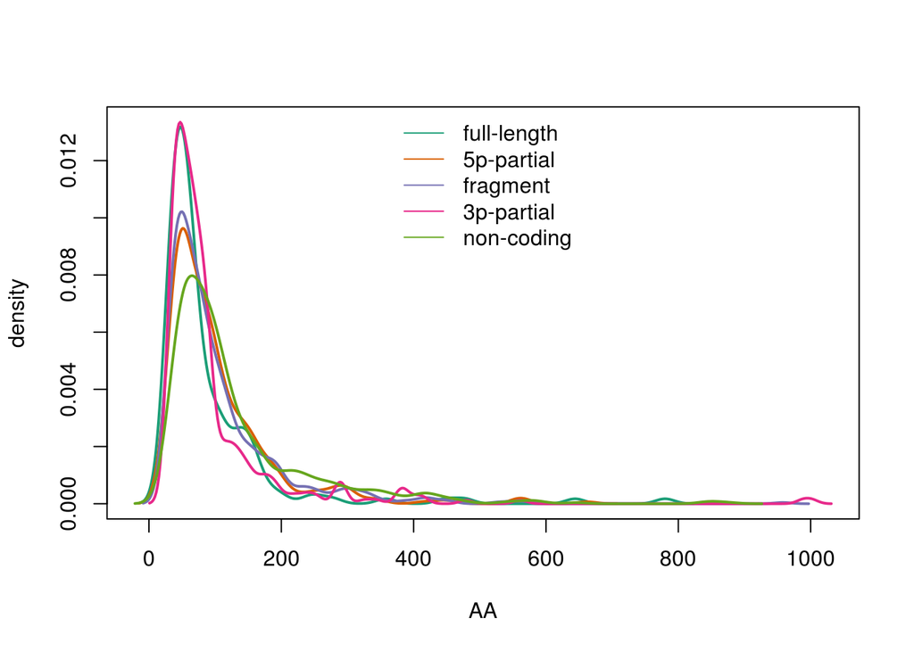

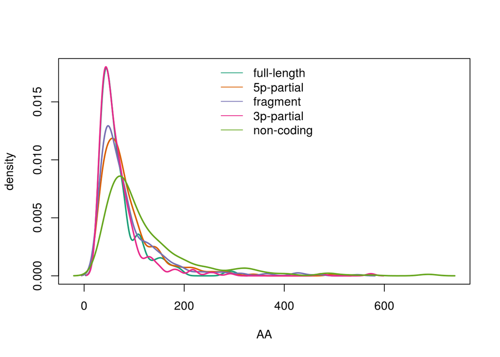

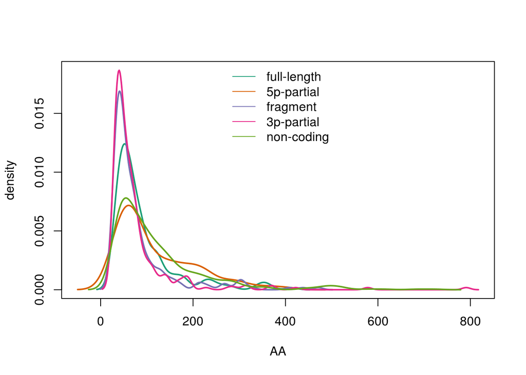

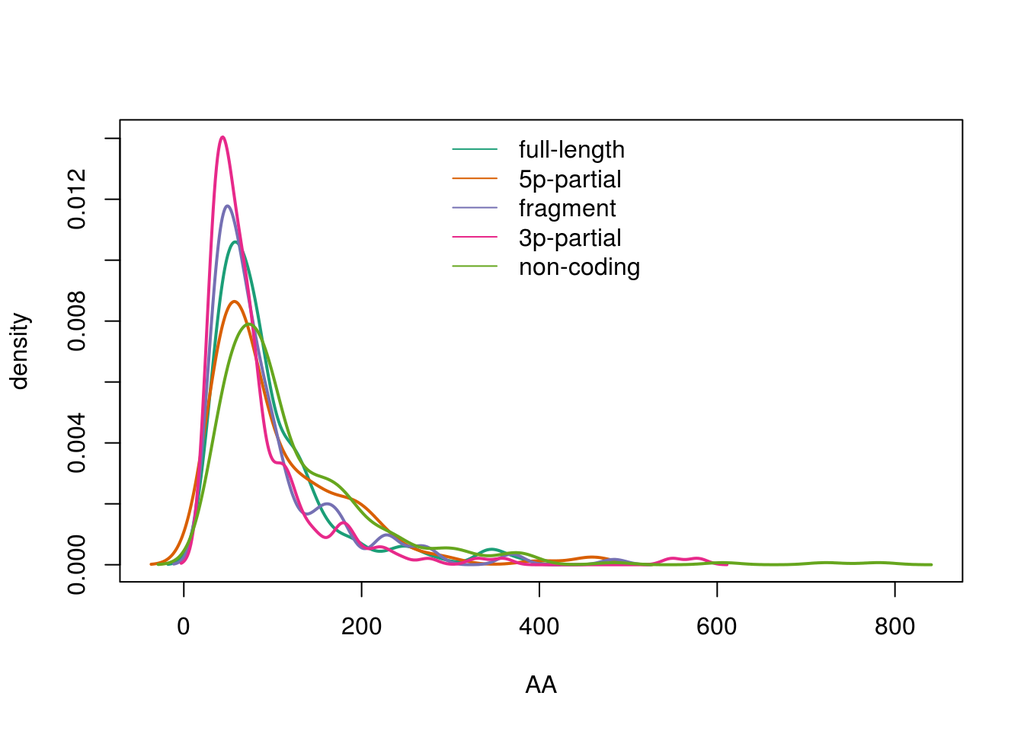

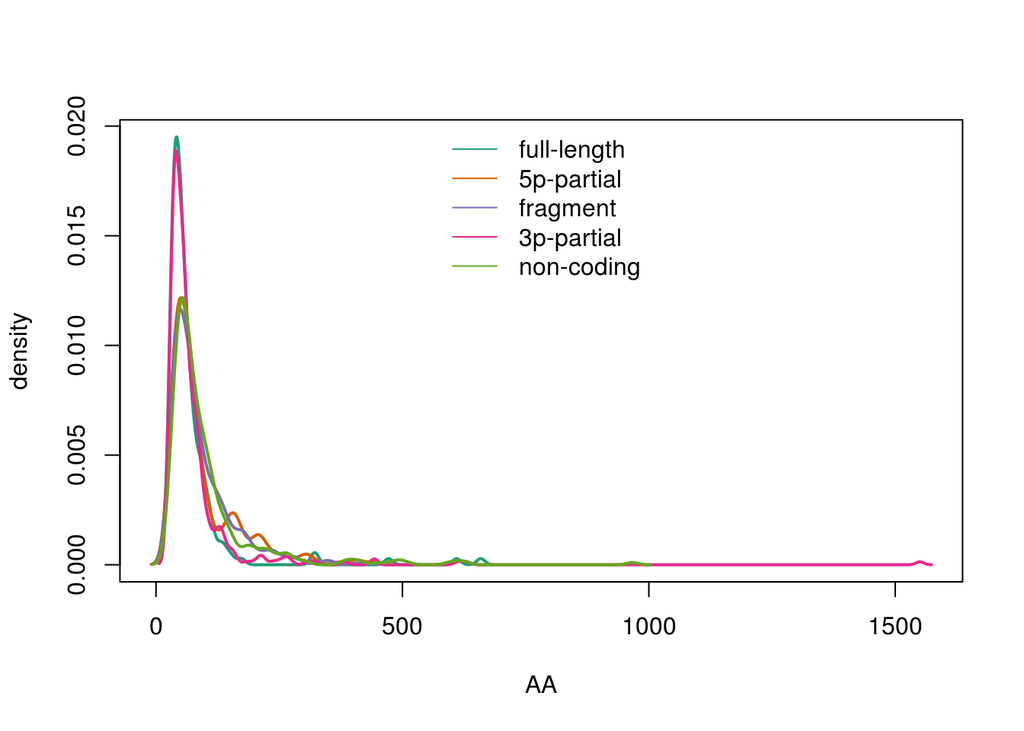

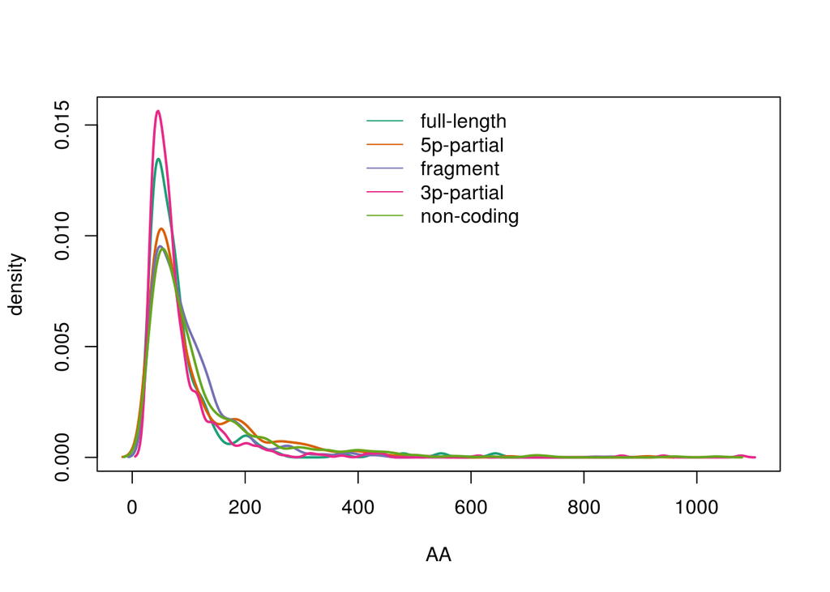

```r
dev.null <- apply(mapply(split,lapply(cProts,width),prot.states),2,plot.multidensity,lwd=2,xlab="AA")
```

And of the 5 types

```r
levels(prot.states[[1]])
```

```
## [1] "full-length" "5p-partial"  "fragment"    "3p-partial"  "non-coding"
```

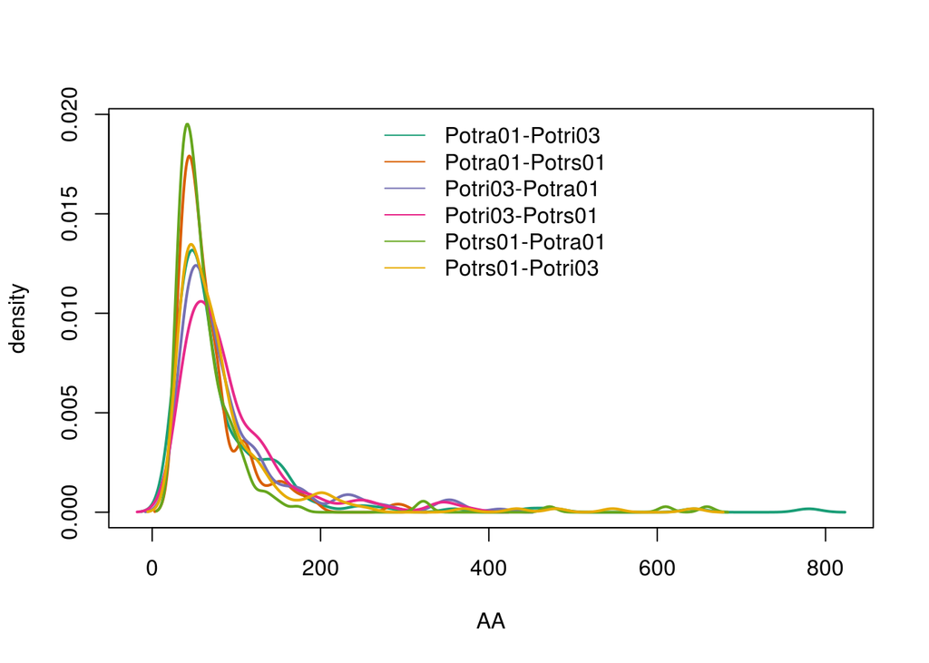

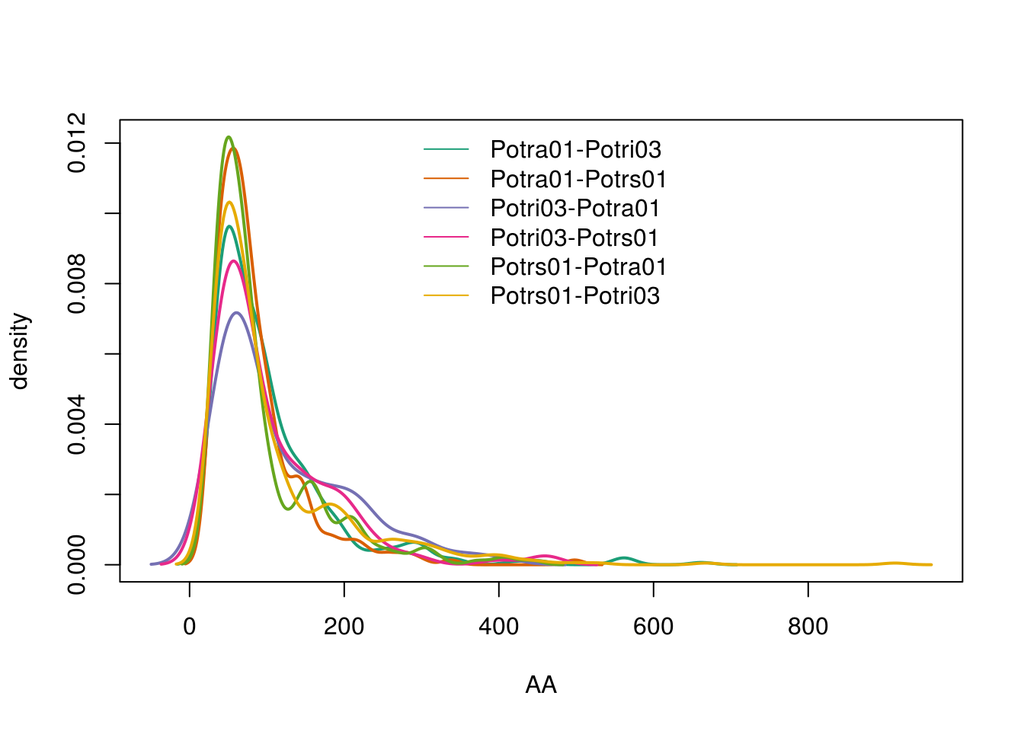

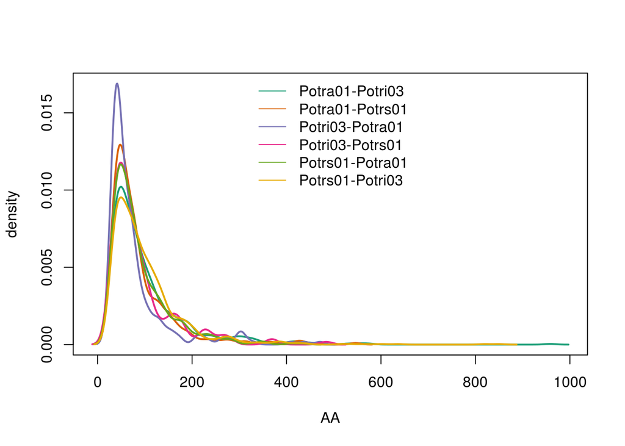

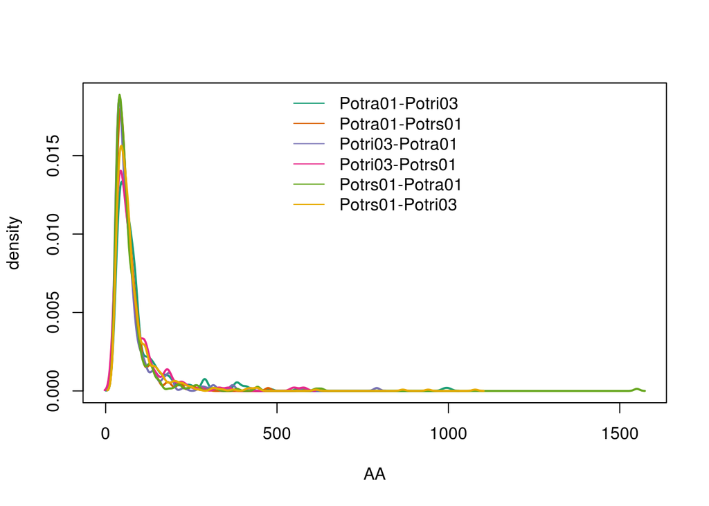

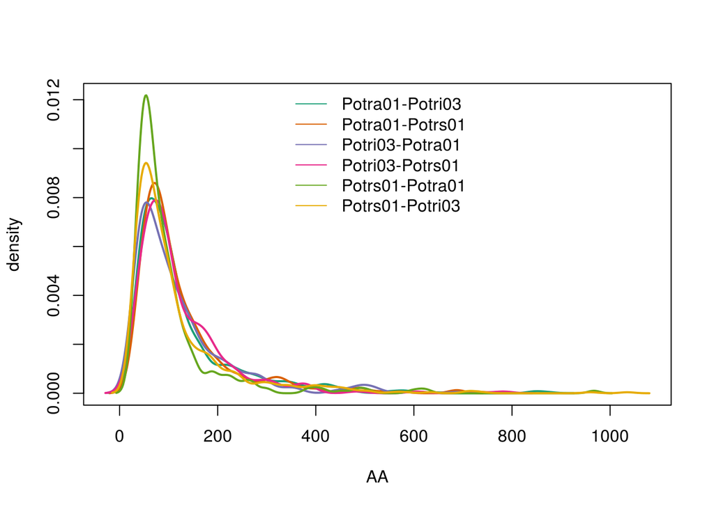

```r
dev.null <- apply(mapply(split,lapply(cProts,width),prot.states),1,plot.multidensity,lwd=2,xlab="AA")
```

Combining it per species

How many genes do these represent per species

```r
Potra.nams <- unique(c(sub("\\.mrna.*","",names(cProts[[3]]),sub("\\.mrna.*","",names(cProts[[5]])))))
Potri.nams <- unique(c(sub("\\.mrna.*","",names(cProts[[1]]),sub("\\.mrna.*","",names(cProts[[6]])))))
Potrs.nams <- unique(c(sub("\\.mrna.*","",names(cProts[[2]]),sub("\\.mrna.*","",names(cProts[[4]])))))
pander(list(
  Potra=length(Potra.nams),
  Potri=length(Potri.nams),
  Potrs=length(Potrs.nams)
))
```

- **Potra**: *856*
- **Potri**: *1716*
- **Potrs**: *1016*

Export the IDs

```r
write(Potra.nams,"Potra01-mapped-gene-without-overlap-in-at-least-one-genome-genes-IDs.txt")
write(Potri.nams,"Potri03-mapped-gene-without-overlap-in-at-least-one-genome-genes-IDs.txt")
write(Potrs.nams,"Potrs01-mapped-gene-without-overlap-in-at-least-one-genome-genes-IDs.txt")
```

How many intersect

```r
Potra.nams <- intersect(sub("\\.mrna.*","",names(cProts[[3]])),sub("\\.mrna.*","",names(cProts[[5]])))
Potri.nams <- intersect(sub("\\.mrna.*","",names(cProts[[1]])),sub("\\.mrna.*","",names(cProts[[6]])))
Potrs.nams <- intersect(sub("\\.mrna.*","",names(cProts[[2]])),sub("\\.mrna.*","",names(cProts[[4]])))
pander(list(
  Potra=length(Potra.nams),
  Potri=length(Potri.nams),
  Potrs=length(Potrs.nams)
))
```

- **Potra**: *136*
- **Potri**: *536*
- **Potrs**: *146*

```r
write(Potra.nams,"Potra01-mapped-gene-without-overlap-to-any-genes-IDs.txt")
write(Potri.nams,"Potri03-mapped-gene-without-overlap-to-any-genes-IDs.txt")
write(Potrs.nams,"Potrs01-mapped-gene-without-overlap-to-any-genes-IDs.txt")
```